# Care and Feeding of Your Biostats Team

Scaling Best Practices in a Large Hybrid SAS/R Team

John Ehrlinger, PhD

Cleveland Clinic,  
Heart, Vascular & Thoracic Institute,  
Cardiovascular Outcome Registries and Research

April 27, 2026

## Cardiovascular Outcome Registries and Research (CORR)

### 1997 CORR

- SAS shop
- Goal: any analyst can pick up any job
- Folder structure with file naming conventions
- A social contract — loosely enforced

### Today

- R and SAS hybrid
- Team grows to 19 (and more)
- Conventions extended to R

We built methods in-house. Now we maintain them too.

Discipline doesn’t scale under production pressure

## CORR Production Scale

[figure not shown]

## CORR Assembly Line

[figure not shown]

## What a Biostatistician Delivers

| Study Researcher | Analysis Report CORR | Manuscript Researcher |
| --- | --- | --- |
| Research questions | Data ingestion | Introduction |
| Statistical approaches | Model building | Methods |
| Communication | Figures & Tables | Results |
|  |  | Discussion |

*“Bus insurance” — any analyst can pick up any job.*

## Reproducibility at scale — Three Focus Areas

1. Data ingestion
2. Model building
3. Figures and tables

Make the safe path the easy path.

# Data Ingestion

Make the safe path the easy path.

## Problem: Data file tracking

Jan 12

cohort.sas7bdat

Initial extract from Data Warehouse

Feb 3, 2:22 PM

cohort_final.sas7bdat

Exclusions applied — but which ones?

Feb 3, 4:47 PM

cohort_final2.sas7bdat

Researcher comments — additional exclusion added

Mar 15

cohort_final_USE_THIS.sas7bdat

PI changed date range — modified date reset on server sync

Apr 2 — today

cohort_final_USE_THIS_v2.sas7bdat

What changed? Nobody remembers.

*Is this the right data? Has it changed?*

## How we’re addressing it In development

**Layer governance on top of existing structure.**

### What we have

```
study_root/
  analyses/      ← jobs
  datasets/      ← *this problem*
  descriptive/
  distributions/
  documents/     ← deliverables
  estimates/     ← cached results
  graphs/        ← pdf
```

### What we’re adding

- Date in the filename  
  never overwrite
- Dataset manifest  
  source, date, parameters
- Checksum  
  detect silent changes
- Audit trail  
  job ↔︎ manifest

## Manifest + checksum in practice In development

**`datasets/built260430.manifest.yml`**

```yaml
dataset:      built260430.sas7bdat
source:       Cardiopulse / STS registry v2.1
pulled_by:    data_manager
pull_date:    2026-04-30
sha256:       a3f8c2d1e4b7f093...
observations: 12847
variables:    428
```

**Register explicitly — separate from build**

```r
digest::digest(
  "datasets/built260430.sas7bdat",
  algo = "sha256", file = TRUE)
```

**Verify before analysis**

```r
stored  <- yaml::read_yaml(
  "datasets/built260430.manifest.yml")$sha256
current <- digest::digest(
  "datasets/built260430.sas7bdat",
  algo = "sha256", file = TRUE)
stopifnot(current == stored)
```

Filename says *when*. Checksum says *whether*.

Rebuild without re-registering → every downstream job fails.  
**That failure is the feature.**

# Model Building

Make the safe path the easy path.

## Problem: R and SAS Environments

**SAS**

- SAS version not locked to a study
- Shared Macro library unversioned
- Shared server

**R & RStudio**

- R version is not locked to a study
- Shared Package library — package versions drift
- Shared server
- Serialized models in `estimates/` **fail to load**
- Results don’t match — or the job won’t run

*Can you reproduce this analysis six months from now?*

## R: `renv` with RStudio projects In flight

Without renv

Packages installed globally — shared across all projects

`update.packages()` breaks other analyses silently

Serialized models in `estimates/` fail to load 6 months later

“Works on my machine” — but not yours

New analyst hunts down exact versions to reproduce results

→

With renv

Day 1 — any analyst, any machine

Isolate the project library and freeze it

renv::init() # isolate library  
renv::install("ehrlinger/hvtiPlotR")  
renv::snapshot() # freeze versions

renv.lock — R 4.4.1 · hvtiPlotR 0.3.2 · …  
commit this; it travels with the project

6 months later — different analyst, different machine

Open .Rproj, run one command

renv::restore() # rebuilds library from renv.lock

Same packages. Same results. The job belongs to the team.

## Problem: Shared function libraries aren’t versioned

**SAS macro library**

- Centralized — everyone calls the same macros
- Not versioned — no record of which version ran
- Changes propagate silently

**R functions**

- Copied at study creation — diverges immediately
- Fixes stay local; no propagation
- In-flight studies never get updates

*SAS: did that update break something? R: did anyone else get that fix?*

## Versioned internal packages In development

An R package **is** a versioned, distributable library.

**Functions in the study folder**

- Frozen at copy
- Fixes don’t propagate
- No version record

**Code in a package**

- One canonical version
- Pull fixes deliberately with `renv::update()`
- Examples travel with code, double as tests

**The hard problems shift — they don’t disappear.**

- Someone must own releases.
- Improvements must be communicated — they don’t propagate automatically.
- Studies must change versions deliberately — **controlled, not automatic.**

## Problem: Code and results live separately

**SAS — partially solved this**

- `.lst` pairs code and output
- Figures still separate files

**R scripts — no equivalent**

- Code and output in separate files
- No standard structure
- Figures disconnected from code

*Can a new analyst navigate this job without asking whoever wrote it?*

## Quarto templates In development

**`report.qmd` = `job.sas`**

- Code and output in one document
- Figures inline
- Renders to HTML, PDF, Word

**Always render before committing.**

**Standard 4-section template**

```markdown
# Data.qmd
Ingestion, exclusions, cohort description

# Methods.qmd
Model specification and assumptions

# Explainability.qmd
Diagnostics, sensitivity checks

# Results.qmd
Tables, figures, interpretation
```

The structure is the contract.

# Figures and Tables

Make the safe path the easy path.

## Problem: Publication-quality graphics

**SAS: `plot.sas`**

- Hard-won publication quality
- Each output target: more manual effort

**R: `ggplot2`**

- Same per-target effort problem
- No shared themes or palettes

*Can we capture that effort once — make figures consistent?*

## R: graphics pipeline In flight

**The package does the hard work. The analyst decorates.**

**Package owns**

- The statistical transform
- The base figure — correct by construction
- Themes: manuscript, PowerPoint, poster

**Analyst owns**

- Axis labels, annotations
- Nothing else needs to change

```r
# Package handles the figure
fig <- plot(corr_analysis(data))

# Analyst decorates to context
fig +
  hv_theme("manuscript") +
  scale_color_brewer(palette = "Set1") +
  annotate("text", ...)
```

*If it looks like the package example, it’s correct.*

## Our visualization packages In flight

**`ggRandomForests`** — github.com/ehrlinger/ggRandomForests

Variable importance, partial depth, minimal depth — `ggplot2` for `randomForestSRC`.

**`hvtiPlotR`** — github.com/ehrlinger/hvtiPlotR

Survival curves, hazard plots, forest plots in CORR themes.

Bridges `ggplot2` to `plot.sas` standards.

*As the science keeps moving and CORR evolves, so do the packages.*

## Survival curves — `ggRandomForests`

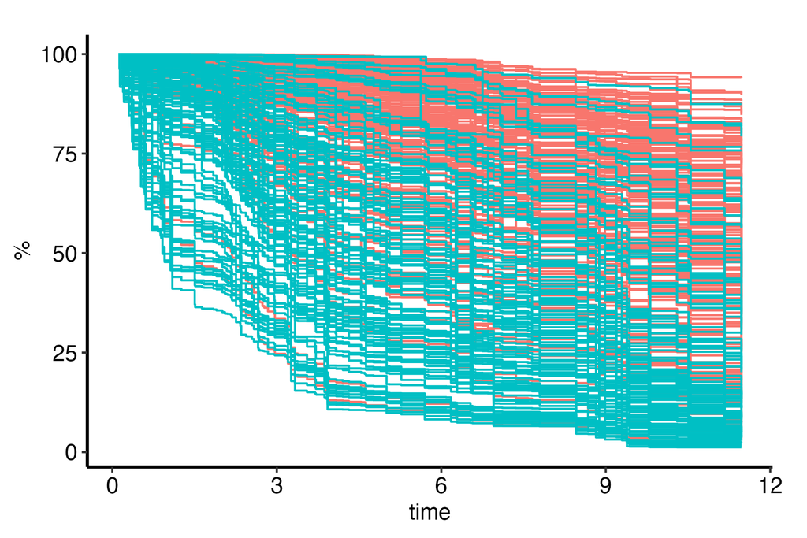

Survival difference between two treatment groups (blue, red)  
`randomForestSRC` fits a survival forest; `ggRandomForests` plots the results.

## Problem: Publication-quality Tables

Right now, this is all SAS.

`gt` and `gtsummary` exist — they aren’t tamed to our standards yet.

That’s next.

## Honestly

|  | Status |
| --- | --- |
| Data Ingestion |  |
| Study folder structure | Adopted — standard |
| Dataset naming + manifests + checksums | In development |
| Model Building |  |
| RStudio Projects + `renv` | In flight — “easy” win |
| Quarto templates | In development |
| `hazard` (SAS), `randomForestSRC` (R) `TemporalHazard` (R) | Adopted In development |
| Figures & Tables |  |
| `ggRandomForests`, `hvtiPlotR` | In flight |
| `hvtiRtables` | Aspirational — coming “soon” |

## The framing shift that mattered

“Reproducibility” → **“Production reliability”**

*“Any biostatistician can pick up any job.”*

Make the safe path the easy path.

## Resources

https://github.com/ehrlinger

| Package |  |
| --- | --- |
| `hazard` (SAS) | github.com/ehrlinger/hazard |
| `TemporalHazard` | github.com/ehrlinger/temporal_hazard |
| `randomForestSRC` | cran.r-project.org/package=randomForestSRC |
| `ggRandomForests` | github.com/ehrlinger/ggRandomForests |
| `hvtiPlotR` | github.com/ehrlinger/hvtiPlotR |
| `hvtiRutilities` | github.com/ehrlinger/hvtiRutilities |

These slides: github.com/ehrlinger/CareFeedingBiostats

Contact: ehrlinj@ccf.org

We’re hiring a biostatistician — Contact me!